# 36-315 Lab 05

SOLUTIONS

Due Saturday, October 2, 2021 (12:00pm)

## Lab 05: Density Estimates and Kolmogorov-Smirnov Tests for Quantitative Data

# Problem 1: Transformations and Details about Changing Smoothed Densities (25 points)

In this lab we will work with a dataset containing information about different foods:

```r
food = read.csv("https://raw.githubusercontent.com/zjbranson/315Fall2021/master/food-facts.csv")
```

This is a carefully chosen, modified subset of the data provided [here](https://www.kaggle.com/openfoodfacts/world-food-facts) by Kaggle.

1. (10pts) Here we will focus on the `energy_100g` variable. For this part, please do the following:
- As a reminder of old material, first make a histogram of the `energy_100g` variable on the **density scale**. There’s no need to specify a `binwidth` for this part, but please `fill` the bars with a non-gray color. Finally, add a smoothed density curve to your plot using `geom_density()`. Please include this plot in your submission.
- Now copy-and-paste the histogram code you just made, and instead make a histogram of the *square root* of `energy_100g`, with an overlayed density. Luckily, it’s really easy to make transformations of variables in `R` and `ggplot`: You simply write `sqrt(energy_100g)` within your `ggplot` code instead of `energy_100`.

For this part, you just need to turn in two histograms, one of `energy_100g` and one of `sqrt(energy_100g)`, both with smoothed density curves added. The difference in shape between the two distributions should be clear: In particular, the distribution of `sqrt(energy_100g)` should look much more clearly bimodal. As we’ll see throughout the course, transforming data can be a great way to highlight certain aspects of distributions.

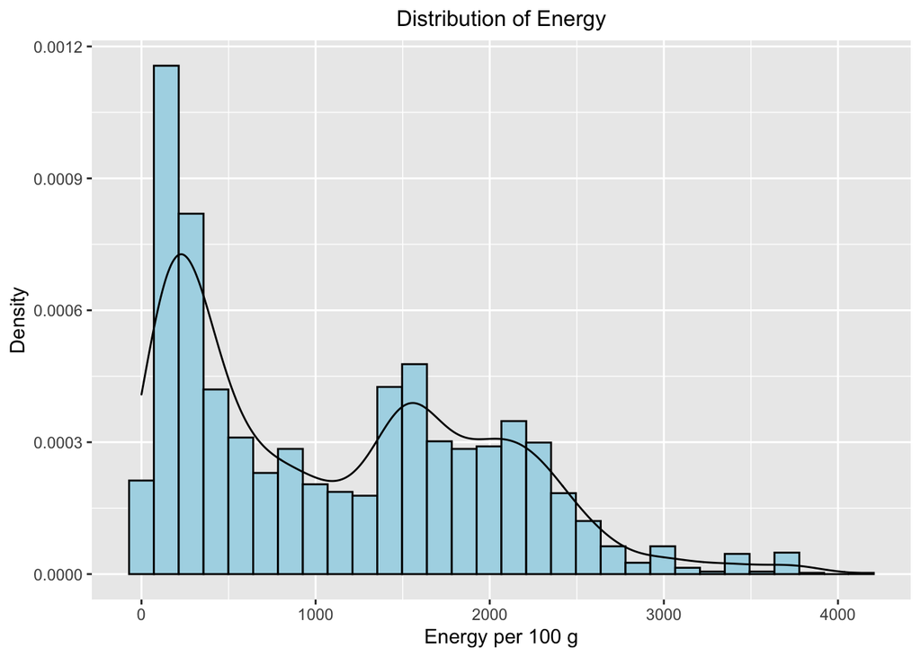

```r
library(tidyverse)
library(gridExtra)
ggplot(food, aes(x = energy_100g)) +
  geom_histogram(aes(y = ..density..),
                 fill = "lightblue", color = "black") +
  geom_density() +
  labs(title = "Distribution of Energy",
       x = "Energy per 100 g", y = "Density") +
  theme(plot.title = element_text(hjust = 0.5, size = 12))
```

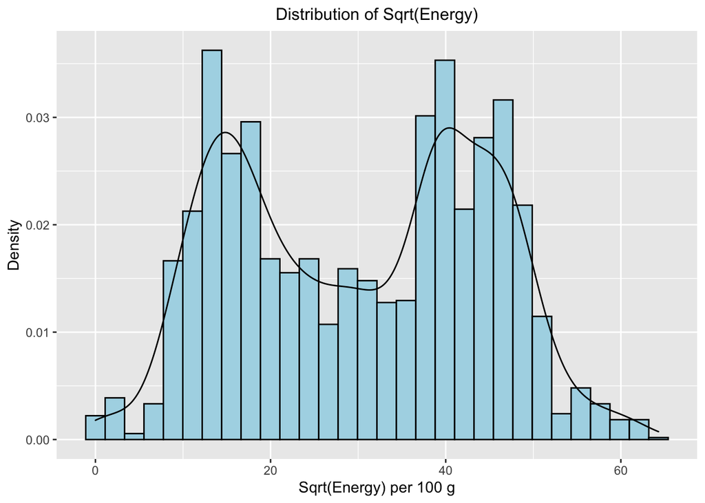

```r
ggplot(food, aes(x = sqrt(energy_100g))) +
  geom_histogram(aes(y = ..density..),
                 fill = "lightblue", color = "black") +
  geom_density() +
  labs(title = "Distribution of Sqrt(Energy)",
       x = "Sqrt(Energy) per 100 g", y = "Density") +
  theme(plot.title = element_text(hjust = 0.5, size = 12))
```

2. (10pts) It can be helpful to understand what bandwidth is being estimated in the smoothed density curve you plotted in Part A. To check what the bandwidth is, write a line of code below that applies the `density()` function to `sqrt(food$energy_100g)`.

```r
density(sqrt(food$energy_100g))
```

```
##
## Call:
##  density.default(x = sqrt(food$energy_100g))
##
## Data: sqrt(food$energy_100g) (2439 obs.);    Bandwidth 'bw' = 2.707
##
##        x                y
##  Min.   :-8.121   Min.   :9.250e-07
##  1st Qu.:12.014   1st Qu.:1.985e-03
##  Median :32.148   Median :1.400e-02
##  Mean   :32.148   Mean   :1.240e-02
##  3rd Qu.:52.283   3rd Qu.:2.172e-02
##  Max.   :72.417   Max.   :2.902e-02
```

You should see some output that displays what the bandwidth is. What bandwidth is being estimated? (Just state the number here.)

*From the above output, we can see that the estimated bandwidth is 2.707.*

After you’ve answered the above question, copy-and-paste your histogram code for `sqrt(energy_100)`, and set `binwidth` equal to the above bandwidth value within `geom_histogram()`. For this part, all you have to do is include the histogram (in addition to stating what the bandwidth is), but you should find that the bars of the histogram now fit the smoothed density curve very well. This is yet another way to automatically pick the `binwidth` for histograms!

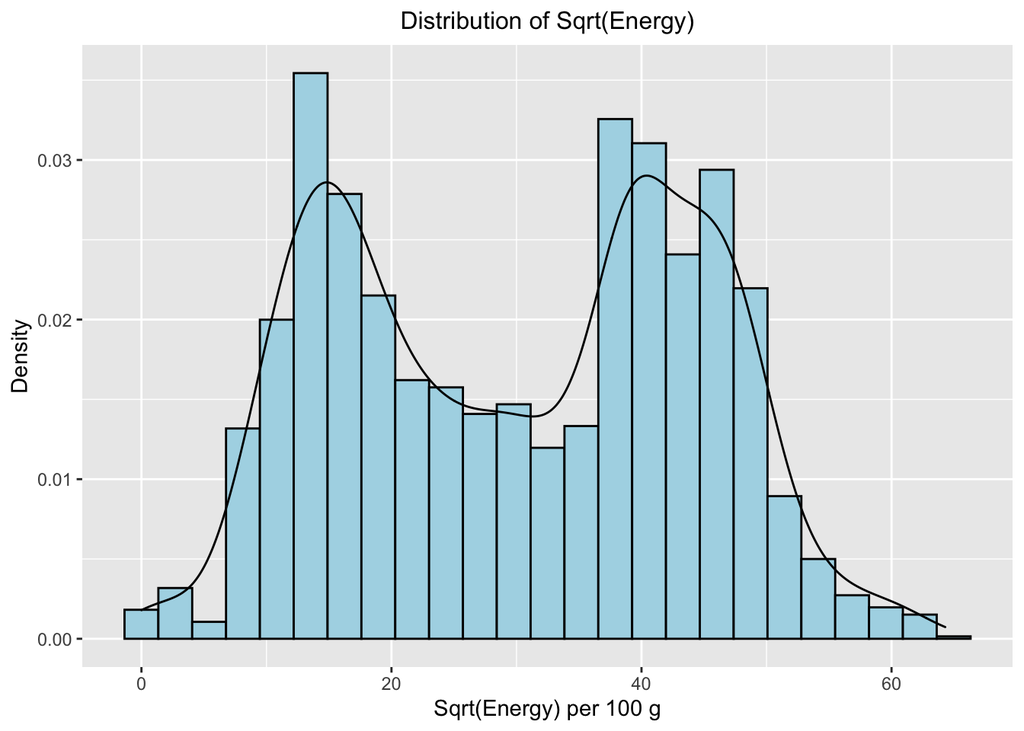

```r
ggplot(food, aes(x = sqrt(energy_100g))) +
  geom_histogram(aes(y = ..density..),
                 fill = "lightblue", color = "black", binwidth = 2.707) +
  geom_density() +
  labs(title = "Distribution of Sqrt(Energy)",
       x = "Sqrt(Energy) per 100 g", y = "Density") +
  theme(plot.title = element_text(hjust = 0.5, size = 12))
```

3. (5pts) Copy-and-paste your code from Part B, and make two final changes to your graph:
- Change the `kernel` argument within the `geom_density()` function. Try a few different values, such as `kernel = "rectangular"`, `kernel = "triangular"`, and others. To see different options for `kernel`, see `kernel` within `help(density)`. Pick your favorite non-Gaussian kernel for your plot.
- Within `geom_density()`, specify a `color`. Also, set `size = 2`. This will make your density curve stand out.

For this part, you only need to turn in a histogram with a smoothed density curve, which uses a non-Gaussian kernel, has a non-default color, and has `size = 2`.

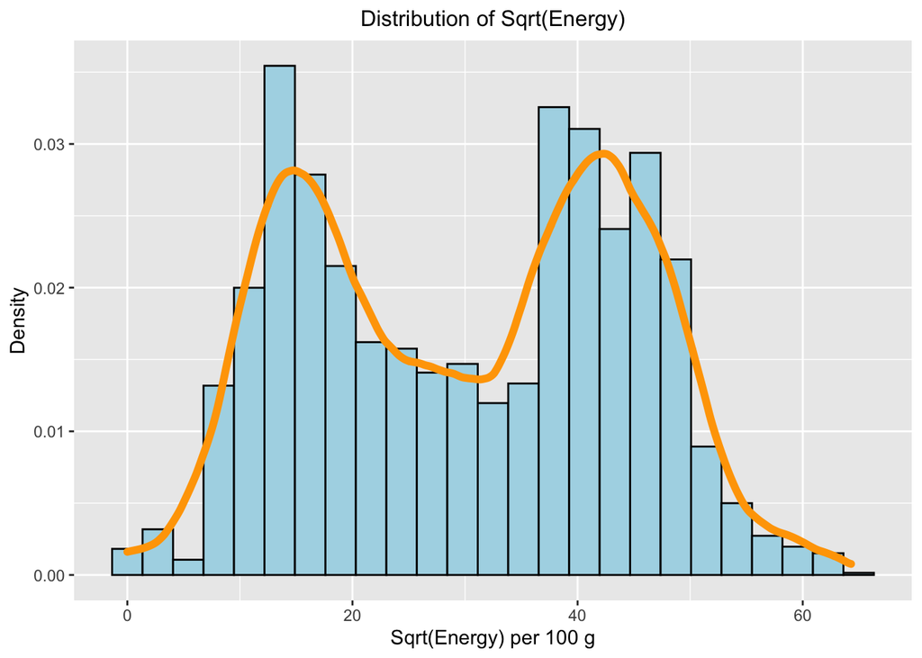

```r
ggplot(food, aes(x = sqrt(energy_100g))) +
  geom_histogram(aes(y = ..density..),
                 fill = "lightblue", color = "black", binwidth = 2.707) +
  geom_density(color = "orange", size = 2, kernel = "epanechnikov") +
  labs(title = "Distribution of Sqrt(Energy)",
       x = "Sqrt(Energy) per 100 g", y = "Density") +
  theme(plot.title = element_text(hjust = 0.5, size = 12))
```

# Problem 2: Comparing Conditional Distributions (40 points)

1. (5pts) Make a conditional smoothed density plot of `sqrt(energy_100g)` given `nutrition_grade_fr` by using `geom_density()` with `color = nutrition_grade_fr`. For this part, you just need to turn in the resulting plot, where there is a separate density curve of `sqrt(energy_100g)` for each level of `nutrition_grade_fr`, each with its own color. There should NOT be any histograms on your plot, just smoothed density curves. If you’re not sure how to do this part, ask for help or revisit the end of Lab4.

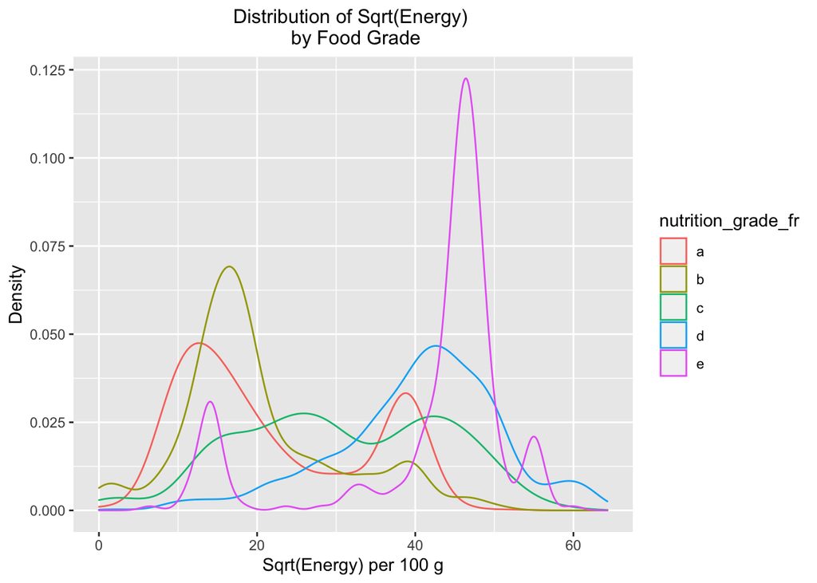

```r
ggplot(food, aes(x = sqrt(energy_100g), color = nutrition_grade_fr)) +
  geom_density() +
  labs(title = "Distribution of Sqrt(Energy) \n by Food Grade",
       x = "Sqrt(Energy) per 100 g", y = "Density") +
  theme(plot.title = element_text(hjust = 0.5, size = 12))
```

2. (5pts) In the plot you made in Part A, you should see that the density is particularly high for Grade E foods. Thus, it may be tempting to think that there are more Grade E foods with `sqrt(energy_100g) > 40` than Grade D foods with `sqrt(energy_100g) > 40`. Using the `nrow()` and `subset()` function, figure out how many Grade D foods there are with `sqrt(energy_100g) > 40`, and how many Grade E foods there are with `sqrt(energy_100g) > 40`. For this part, you just need to state how many Grade D foods there are with `sqrt(energy_100g) > 40` and how many Grade E foods there are with `sqrt(energy_100g) > 40`; however, it’s useful to think about how that compares/contrasts with your smoothed density curve in Part A.

```r
nrow( subset(food, sqrt(energy_100g) > 40 & nutrition_grade_fr == "d" ) )
```

```
## [1] 349
```

```r
nrow( subset(food, sqrt(energy_100g) > 40 & nutrition_grade_fr == "e" ) )
```

```
## [1] 227
```

*From the above output, we can see that there are 349 Grade D foods with `sqrt(energy_100g) > 40`, but only 227 Grade E foods with `sqrt(energy_100g) > 40`. So, why is the density higher for Grade E foods than Grade D foods?*

*It’s important to remember that each density is relative only to a particular category. Thus, within Grade E foods specifically, we know that there a relatively high number of foods with `sqrt(energy_100g) > 40`. Meanwhile, within Grade D foods specifically, there seems to be a relatively fewer number of foods with `sqrt(energy_100g) > 40`. However, this does not imply that the nominal number of Grade E foods with `sqrt(energy_100g) > 40` is greater than the nominal number of Grade D foods with `sqrt(energy_100g) > 40`.*

*To put it another way: Each of the above smoothed density curves integrates to 1. Thus, each density is indeed a probability density function in its own righ; these densities aren’t necessarily comparable if the sample sizes between different grades of food are different, which is indeed the case here:*

```r
table(food$nutrition_grade_fr)
```

```
##
##   a   b   c   d   e
## 726 335 500 594 284
```

3. (5 points) To better see how each density compares to each other, we’ll now make a “proportional density plot.” We haven’t talked about this plot before, but it looks pretty cool, and you’ll be able to understand it given what we’ve learned this week. To make the proportional density plot, copy-and-paste your code from Part A, set `nutrition_grade_fr` equal to `fill` instead of `color`, and set `position = "fill"` within `geom_density()`. Change the `alpha` value to something you think is appropriate. Be sure that your plot is appropriately labeled.

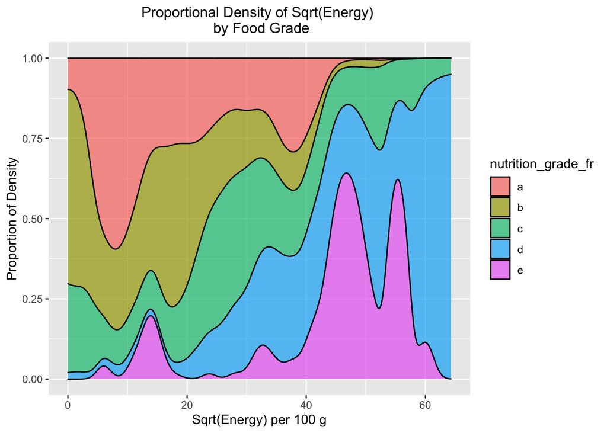

```r
ggplot(food, aes(x = sqrt(energy_100g), fill = nutrition_grade_fr)) +
  geom_density(position = "fill", alpha = 0.7) +
  labs(title = "Proportional Density of Sqrt(Energy) \n by Food Grade",
       x = "Sqrt(Energy) per 100 g", y = "Proportion of Density") +
  theme(plot.title = element_text(hjust = 0.5, size = 12))
```

4. (10pts) We could use the plot in Part A to visually compare and contrast the distribution of `sqrt(energy_100g)` for different values of `nutrition_grade_fr`. Now we’ll consider statistical tests to formally compare these different distributions. For this part, do the following:
- Test whether `sqrt(energy_100g)` has the same variance across different values of `nutrition_grade_fr`. To test whether different groups have the same variance, we use Bartlett’s test via the `bartlett.test()` function. Specifically, run Bartlett’s test using `bartlett.test(outcome~group, data = food)`, with `outcome` correctly specified and `group` correctly specified. After running the test, state your formal statistical conclusion from the test, and explain how you arrived at your answer using Bartlett’s test. In your answer, be sure to state the null hypothesis for this test (if you can’t remember, ask for help or check back at the lecture notes).

```r
bartlett.test(sqrt(energy_100g) ~ nutrition_grade_fr, data = food)
```

```
##
##  Bartlett test of homogeneity of variances
##
## data:  sqrt(energy_100g) by nutrition_grade_fr
## Bartlett's K-squared = 35.299, df = 4, p-value = 4.034e-07
```

*We see that the p-value is quite small and certainly less than 0.05; thus, we reject the null hypothesis that the variance of `sqrt(energy_100g)` is the same across all `nutrition_grade_fr` values, thereby concluding that there is at least one pair of grades that differ in terms of their variance of `sqrt(energy_100g)`.*

- Test whether `sqrt(energy_100g)` has the same mean across different values of `nutrition_grade_fr`. To do this, we use one-way ANOVA. So, for this part, use `oneway.test(outcome ~ group, data = food)`, where `outcome` and `group` are appropriate specified. Furthermore, within `oneway.test()`, specify `var.equal = FALSE` if you think the variances are not equal (according to Bartlett’s test) or specify `var.equal = TRUE` if you think the variances are equal (according to Bartlett’s test). After running the test, state your formal statistical conclusion from the test, and explain how you arrived at your answer. In your answer, be sure to state the null hypothesis for this test (if you can’t remember, ask for help or check back at the lecture notes).

```r
oneway.test(sqrt(energy_100g) ~ nutrition_grade_fr, data = food, var.equal = FALSE)
```

```
##
##  One-way analysis of means (not assuming equal variances)
##
## data:  sqrt(energy_100g) and nutrition_grade_fr
## F = 390.76, num df = 4.0, denom df = 1014.6, p-value < 2.2e-16
```

*First, note that we set `var.equal = FALSE`, because we concluded from Bartlett’s test that the population-level variances differ. From this one-way ANOVA test, we see that the p-value is quite small and certainly less than 0.05; thus, we reject the null hypothesis that the mean of `sqrt(energy_100g)` is the same across all `nutrition_grade_fr` values, thereby concluding that there is at least one pair of grades that differ in terms of their means of `sqrt(energy_100g)`.*

5. (15pts) Bartlett’s test and one-way ANOVA are limited in that they cannot tell us *which* means and variances are different, only that differences may exist. Thus, it’s common to conduct follow-up analyses between subgroups if we believe differences exist. (There can often be issues with multiple testing here, but we’ll ignore that for this lab.) For this question, we’ll focus on Grade B and Grade D foods specifically. It’ll be helpful to define the following dataset:

```r
food.bd = subset(food, nutrition_grade_fr == "b" | nutrition_grade_fr == "d")
```

Using this dataset, do the following:

- Run Bartlett’s test using `energy_100g` as the outcome. State your formal statistical conclusion from this test.

```r
bartlett.test(energy_100g ~ nutrition_grade_fr, data = food.bd)
```

```
##
##  Bartlett test of homogeneity of variances
##
## data:  energy_100g by nutrition_grade_fr
## Bartlett's K-squared = 82.357, df = 1, p-value < 2.2e-16
```

*We see that the p-value is quite small and certainly less than 0.05; thus, we reject the null hypothesis that the variance of `energy_100g` is the same between Grade B and Grade D foods, thereby concluding that they differ.*

- Run Bartlett’s test using `sqrt(energy_100g)` as the outcome. State your formal statistical conclusion from this test.

```r
bartlett.test(sqrt(energy_100g) ~ nutrition_grade_fr, data = food.bd)
```

```
##
##  Bartlett test of homogeneity of variances
##
## data:  sqrt(energy_100g) by nutrition_grade_fr
## Bartlett's K-squared = 0.65383, df = 1, p-value = 0.4187
```

*Interestingly, we see that the p-value is fairly large: 0.4187, which is larger than 0.05. Thus, we fail to reject the null hypothesis that the variance of `sqrt(energy_100g)` is the same between Grade B and Grade D foods.*

- Using the `food.bd` dataset, make a conditional smoothed density plot of `energy_100g` given `nutrition_grade_fr` by using `geom_density()` with `color = nutrition_grade_fr`. (This should just involve copy-and-pasting code from Part A and changing it slightly.)

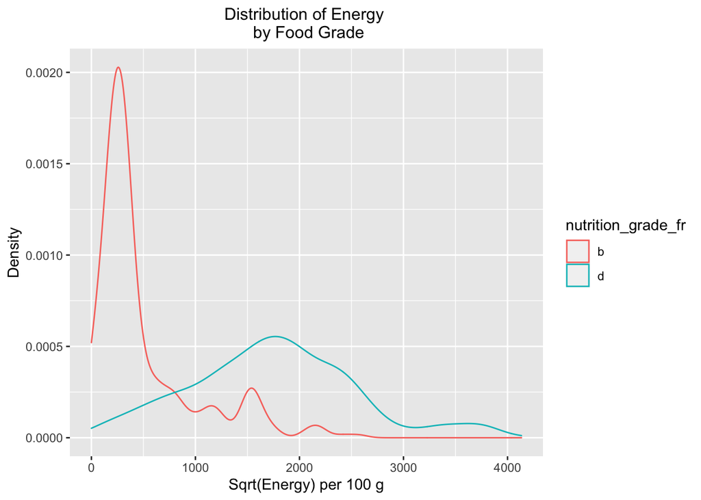

```r
ggplot(food.bd, aes(x = energy_100g, color = nutrition_grade_fr)) +
  geom_density() +
  labs(title = "Distribution of Energy \n by Food Grade",
       x = "Sqrt(Energy) per 100 g", y = "Density") +
  theme(plot.title = element_text(hjust = 0.5, size = 12))
```

- Using the `food.bd` dataset, make a conditional smoothed density plot of `sqrt(energy_100g)` given `nutrition_grade_fr` by using `geom_density()` with `color = nutrition_grade_fr`. (This should just involve copy-and-pasting code from Part A and changing it slightly.)

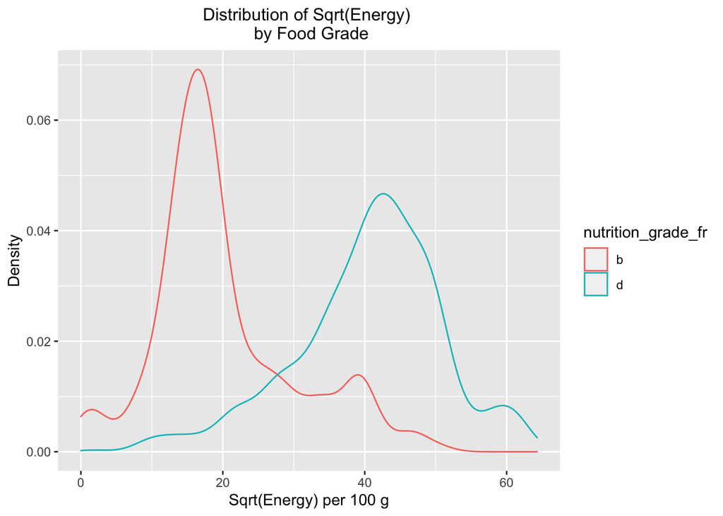

```r
ggplot(food.bd, aes(x = sqrt(energy_100g), color = nutrition_grade_fr)) +
  geom_density() +
  labs(title = "Distribution of Sqrt(Energy) \n by Food Grade",
       x = "Sqrt(Energy) per 100 g", y = "Density") +
  theme(plot.title = element_text(hjust = 0.5, size = 12))
```

*As we can see from the above plots, it does indeed appear that the variances of `energy_100g` are quite different, but not so much the variances of `sqrt(energy_100g)`. The takeaway for this question is that transformations - such as square roots - can sometimes alter our conclusions from hypothesis tests. Indeed, it’s not always the case that the corresponding null hypotheses will align: For example, it is not necessarily the case that $\sigma^2_B = \sigma^2_D$ implies $\tilde{\sigma}^2_B = \tilde{\sigma}^2_D$, where the $\sigma^2$ terms denote the variance of `energy_100g`, and the $\tilde{\sigma}^2$ terms denote the variance of `sqrt(energy_100g)`.*

For this part, all you need to do is run and state your results from the Bartlett’s tests, as well as produce the plots. However, comparing the two conditional density plots should help you understand the results from the tests. **Note**: Bartlett’s test is known to be sensitive to non-Normality, in that it has a strong tendency to reject the null hypothesis when data are very non-Normally distributed.

# Problem 3: Running and Visualizing KS Tests (35 points)

For this problem, we’ll just work with the `energy_100g` variable, and NOT the square-root transformation.

1. (5pts) As a review of previous material, first use the Kolmogorov-Smirnov (KS) test to assess if `energy_100g` for Grade D foods follows a Normal distribution. First, let’s define a dataset, `food.d`, which contains just the Nutrition Grade D foods:

```r
food.d = subset(food, nutrition_grade_fr == "d")
```

Then, to save you some time, here’s template code you can use to run the test:

```r
mean.est = mean(food.d$energy_100g)
sd.est = sd(food.d$energy_100g)
ks.test(food.d$energy_100g, "pnorm", mean = mean.est, sd = sd.est)
```

```
## Warning in ks.test(food.d$energy_100g, "pnorm", mean = mean.est, sd = sd.est):
## ties should not be present for the Kolmogorov-Smirnov test
```

```
##
##  One-sample Kolmogorov-Smirnov test
##
## data:  food.d$energy_100g
## D = 0.041825, p-value = 0.2498
## alternative hypothesis: two-sided
```

State the p-value and your formal conclusion from this test.

(Note: You can ignore the warning that’s displayed by the KS test here.)

*We see that the p-value is 0.2498; thus, we fail to reject the null hypothesis that `energy_100g` is Normally distributed for Grade D foods.*

2. (10pts) As discussed in class, the KS test relies on the empirical cumulative distribution functions (CDFs); so, let’s learn how to plot empirical CDFs. To do this, we can use base `R`. Follow these steps:
- The `ecdf()` function computes the empirical CDF. First try typing `ecdf(x = food.d$energy_100g)`.
- Now plot the empirical CDF by putting the `plot()` function “around” the `ecdf()` code you wrote earlier. In other words, your code should look like `plot(ecdf(...))`.
- If you try making this plot, it’ll look a bit messy with a lot of dots. To get rid of those dots, write `pch = NA` within `plot()` (but not within `ecdf()`!)

You should end up with the empirical CDF that looks like the “step functions” we’ve been talking about in class this week. Note that the steps are quite small, because the sample size of `food.d` is pretty large (about 600).

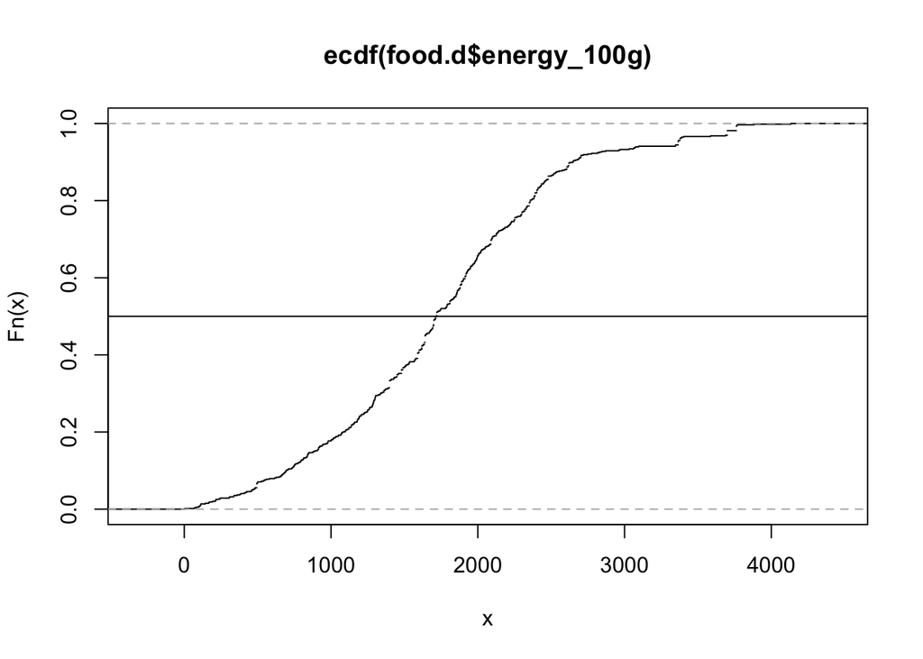

```r
plot(ecdf(food.d$energy_100g), pch = NA)
abline(h = 0.5)
```

After you’ve made your empirical CDF plot, answer the following in 1-2 sentences: How would you use the plot to report the median of `energy_100g` for Grade D foods? To help answer this question, draw a horizontal line on your empirical CDF plot by adding `abline(h = ?)` to your code, where `?` is filled in with a value that you think is appropriate to answer this question. Your submission for this part should just be the empirical CDF plot with a horizontal line, as well as 1-2 sentences answering the median question.

*As discussed in class, the empirical CDF $\hat{F}(x)$ denotes the proportion of observations that are less than or equal to some value $x$. In the above empirical CDF plot, we drew a horizontal line at 0.5; thus, we are considering the point where $\hat{F}(x) = 0.5$. In other words, we are considering the $x$ value such that 50% of the data is less than or equal to that value - that is exactly the definition of the median. Thus, we can use the empirical CDF plot to figure out the median by simply picking out the $x$ value that leads to $\hat{F}(x) = 0.5$ - i.e., the $x$ value where the empirical CDF “hits” that horizontal line. More generally, empirical CDF plots can be used to figure out any quantile, not just the 50% quantile.*

3. (10pts) In Part A we used the KS test to test Normality; another test for Normality that’s known to have higher statistical power in detecting non-Normality is the Shapiro-Wilk test. The null hypothesis for the Shapiro-Wilk test is that the data is Normally distributed; thus, the Shapiro-Wilk test can only be used to test Normality, whereas the KS test can be used to test any distribution.

In this part, run the Shapiro-Wilk test for `energy_100g` within the `food.d` dataset. To do this, simply uncomment this line of code:

```r
shapiro.test(food.d$energy_100g)
```

```
##
##  Shapiro-Wilk normality test
##
## data:  food.d$energy_100g
## W = 0.98348, p-value = 2.931e-06
```

You don’t even have to input the sample mean and standard deviation! Also, Martin Wilk is probably sad that this function is just called `shapiro.test()`…For this part, answer the following after you’ve run the Shapiro-Wilk test:

- What is your conclusion from the Shapiro-Wilk test? How does this compare to your conclusion from Part A?

*For this test, we observe a very small p-value that’s certainly less than 0.05. Thus, according to the Shapiro-Wilk test, we reject the null hypothesis that `energy_100g` for Grade D foods are Normally distributed, in favor of the alternative that it is not Normally distributed. This differs from the conclusion we made in the KS test, where we failed to reject this null hypothesis.*

- In 1-2 sentences, explain why the Shapiro-Wilk test gives a different p-value from the KS test, with the knowledge that the Shapiro-Wilk test has more power than the KS test.

*Because the Shapiro-Wilk test has more power, we expect it to reject more often, at least when the null hypothesis is false (i.e., when the data are not Normally distributed). Meanwhile, when the null hypothesis is true, we would expect both the KS test and the Shapiro-Wilk test to falsely reject the null hypothesis about 5% of the time (because both are valid tests for the null hypothesis that the data are Normally distributed). Thus, in general, we would expect the Shapiro-Wilk test to reject more frequently than the KS test, as we have seen here.*

4. (5pts) Finally, we’re going to assess if `energy_100g` has a different distribution for Grade B and Grade D foods using a two-sample KS test. Use the following code to run a two-sample KS test:

```r
food.b = subset(food, nutrition_grade_fr == "b")
ks.test(food.b$energy_100g, food.d$energy_100g)
```

```
##
##  Two-sample Kolmogorov-Smirnov test
##
## data:  food.b$energy_100g and food.d$energy_100g
## D = 0.69417, p-value < 2.2e-16
## alternative hypothesis: two-sided
```

where you must appropriately define `food.b`. State your formal conclusion for this test; in your conclusion, be sure to mention what the null hypothesis is for this test.

*From the above test, we see that we get a very small p-value that’s certainly less than 0.05. Thus, we reject the null hypothesis that the distribution of `energy_100g` is the same for Grade B and Grade D foods, thereby concluding that they differ. [Indeed, if we look back at the smoothed density plot we made in Question 2E, we see that these distributions have very different means, variances, and shape, so it is unsurprising that we reject the null hypothesis here.]*

5. (5pts) Now let’s visualize what the two-sample KS test is doing. To do this, follow these steps:
- Similar to Part B, create an empirical CDF plot for `energy_100g` for the `food.d` dataset. Don’t include a horizontal line here.
- Now add a line for the empirical CDF of `energy_100g` for `food.b`. To do this, add this line of code: `lines(ecdf(...), pch = NA, col = "red")`, where `...` is appropriately filled in.

For this part, you only need to turn in a plot of two empirical CDFs (one that’s black, one that’s red).

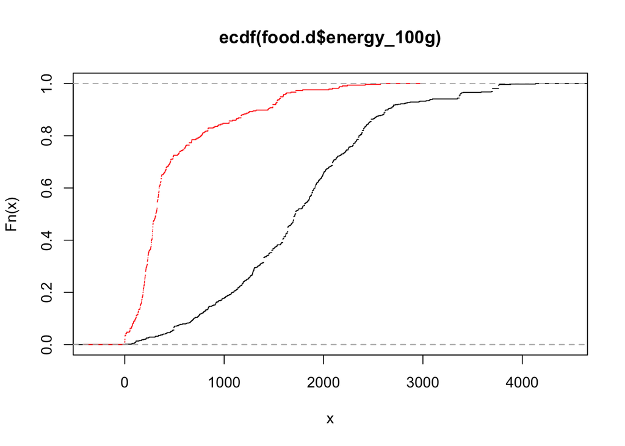

```r
plot(ecdf(food.d$energy_100g), pch = NA)
lines(ecdf(food.b$energy_100g), pch = NA, col = "red")
```

*[We can see that the empirical CDFs are quite far away from each other: The above plot indicates that Grade B foods have mostly low values of `energy_100g`, whereas Grade D foods tend to have higher values, which is also what we saw earlier in the smoothed density plot. Because the empirical CDFs are far away from each other, the two-sample KS test rejects the null hypothesis in this case.]*